# 对爬虫17年底爬取的拉勾网数据分析招聘职位进行分析

```python
# 准备工作（使中文正常显示）
# 用文本编辑器打开下面命令得到的 matplotlibrc文件，将以 font.family和 font.sans-serif开头的两行前的注释符(#)删掉，
# 并在“font.sans-serif:”后加上SimHei,更改后结果如 font.sans-serif  : SimHei, msyh, DejaVu Sans, ......

import matplotlib
print(matplotlib.matplotlib_fname())

# 再将附带的字体文件放入matplotlib同级目录下的\fonts\ttf目录中
```

```
C:\Users\wjh\Anaconda3\lib\site-packages\matplotlib\mpl-data\matplotlibrc
```

```python
# 接着删除下面得到的用户目录中.matplotlib/下的所有带cache的文件及文件夹后重启此ipynb

print (matplotlib.get_configdir())
```

```
C:\Users\wjh\.matplotlib
```

```python
# python3
# _*_ coding:utf-8 _*_
# 导入所需的包
import numpy as np
import pandas as pd
import seaborn as sns
import matplotlib.pyplot as plt
from wordcloud import WordCloud
% matplotlib inline
matplotlib.rcParams['font.sans-serif'] = ['SimHei']
```

```python
# 读取数据
df = pd.read_excel('la_gou.xlsx')
```

```python
# 删除不需要的变量
df_clean1 = df.drop(['Index', 'home_page', 'address', 'url', 'date_time'],axis=1)
```

```python
# 删除冗余行
df_clean = df_clean1.drop_duplicates(['company', 'title', 'description'])
df_clean=df_clean.reset_index(drop=True)
```

## 一、职位在地域方面的区别：

```python
city_series = df_clean['city'].value_counts()
y_cor = list(city_series.values)
x_cor = list(np.arange(len(y_cor)))
```

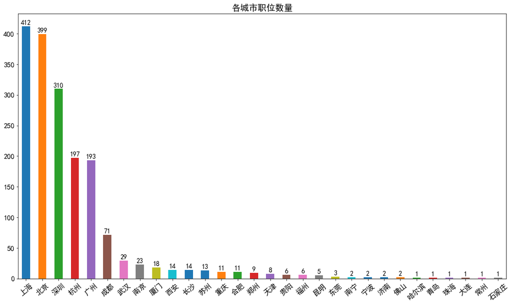

```python
city_series.plot(kind='bar', figsize=(18,10), fontsize=15, rot=40);
for x,y in zip(x_cor,y_cor):
    plt.text(x, y+1, '%s' % y, ha='center', va= 'bottom',fontsize=14);
plt.title(u'各城市职位数量', size = 18);
plt.show();
```

### 分析结果显示，与以往媒体报道的北京互联网发展遥遥领先不同，上海至少在数据分析职位方面的需求超过了北京，但也只是略超，同时，深圳与上海和北京相比，需求数量差距也不是非常大，其次杭州和广州的需求比较大，且两者几乎无差距，再者就是成都有一定需求，其它城市的需求非常少，可忽略了。总体来说与人们对互联网强城市的印象相符

## 二、薪资概况：

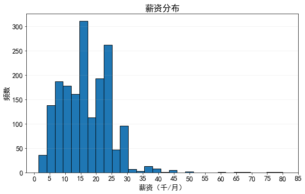

```python
# 由于招聘给出的薪资是一个区间，故采用其上限和下限间的中值进行分析
df_clean['salary_median'].hist(figsize=(10,6), bins=30, edgecolor='k', grid=False);
plt.xlabel(u'薪资（千/月）', size=15);
plt.ylabel(u'频数', size=15);
plt.title(u'薪资分布', size=18);
plt.xticks(range(0,90,5), size=15);
plt.yticks(size=15);
plt.grid(axis='y', alpha=0.2);
```

### 从分布看，薪资差异较大，有大量五千到一万五之间的职位，一万五到两万五差不多和前面的一样多，这两部分占了绝大多数，超过三万的寥寥无几，最高有达到七万多的。

## 工作经验要求：

```python
df_clean['experience'].value_counts().index # 注意值中有空格
```

```
Index(['3-5年 ', '1-3年 ', '不限 ', '5-10年 ', '1年以下 ', '应届毕业生 ', '10年以上 '], dtype='object')
```

```python
# 查看各值频数
df_clean['experience'].value_counts()
```

```
3-5年      732
1-3年      621
不限        234
5-10年     139
1年以下       35
应届毕业生       3
10年以上       2
Name: experience, dtype: int64
```

```python
# 应届毕业生和10年以上人数很少，将应届毕业生归类到一年以下，将10年以上归类到5-10年，并去掉空格
for i in df_clean.index:
    df_clean.loc[i,'experience'] = df_clean.loc[i,'experience'].strip()
    if df_clean.loc[i,'experience'] == u'应届毕业生':
        df_clean.loc[i,'experience'] = u'1年以下'
    if df_clean.loc[i,'experience'] == u'10年以上':
        df_clean.loc[i,'experience'] = u'5-10年'
```

```python
experience_freq = df_clean['experience'].value_counts()
experience_freq
```

```
3-5年     732
1-3年     621
不限       234
5-10年    141
1年以下      38
Name: experience, dtype: int64
```

```python
experience_sort = pd.Series([38, 621, 732, 141, 234], index=[u'1年以下',u'1-3年',u'3-5年',u'5-10年',u'不限'])
```

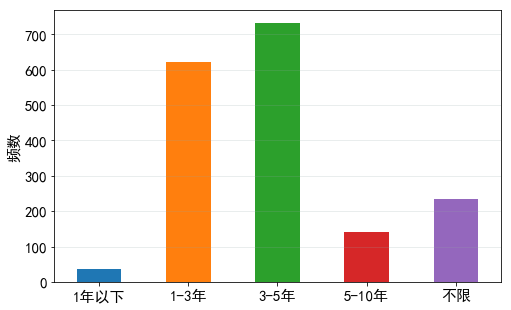

```python
experience_sort.plot(kind='bar',figsize=(8,5), fontsize=15, rot=0);
plt.grid(color='#95a5a6', linewidth=1,axis='y',alpha=0.2)
plt.xticks(range(5), experience_sort.index, size=15)
plt.ylabel(u'频数', size=15);
```

### 绝大部分岗位都要求有工作经验，3-5年的最多，其次是1-3年的，5-10年的专家级也有一定需求，还有一些不限经验的，可能是新领域或实习之类的

## 互联网热点城市薪资概况：

```python
salary_groupby_city = df_clean.groupby('city')['salary_median']
large_city = city_series[0:6].index
salary_of_city = []
for city in large_city:
    salary_value = salary_groupby_city.get_group(city).values #得到各城市对应的薪水的数组
    salary_of_city.append(salary_value)
```

```python
print(plt.style.available)
```

```
['bmh', 'classic', 'dark_background', 'fivethirtyeight', 'ggplot', 'grayscale', 'seaborn-bright', 'seaborn-colorblind', 'seaborn-dark-palette', 'seaborn-dark', 'seaborn-darkgrid', 'seaborn-deep', 'seaborn-muted', 'seaborn-notebook', 'seaborn-paper', 'seaborn-pastel', 'seaborn-poster', 'seaborn-talk'…
```

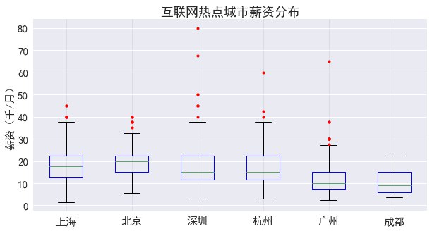

```python
plt.style.use('seaborn-darkgrid')
matplotlib.rcParams['font.sans-serif'] = ['SimHei']# 对于有些seaborn的style，必须同时运行此命令，否则还是不显示中文
plt.figure(figsize=(10,5));
plt.boxplot(salary_of_city, boxprops = {'color':'blue'},
            flierprops = {'markerfacecolor':'red','color':'black','markersize':4});
plt.title(u'互联网热点城市薪资分布', size=18);
plt.ylabel(u'薪资（千/月）',size=15);
plt.xticks(np.arange(6)+1,large_city, size=15);
plt.yticks(size=15);
plt.grid(color='#95a5a6', linewidth=1,axis='x',alpha=0.2);
```

### 从结果看，北京的月薪中位数最高，在2万元，其次是上海，在1.75万左右，深杭在1.5万左右，广州成都只有1万，但薪资最高的部分在深圳

## 工作经验对薪资的影响：

```python
salary_groupby_experience = df_clean.groupby('experience')['salary_median']
```

```python
salary_of_experience = []
for experience in experience_sort.index:
    salary_value = salary_groupby_experience.get_group(experience).values
    salary_of_experience.append(salary_value)
```

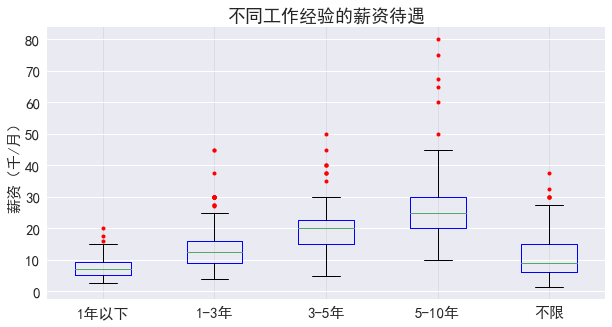

```python
plt.figure(figsize=(10,5));
plt.boxplot(salary_of_experience, boxprops = {'color':'blue'},
            flierprops = {'markerfacecolor':'red','color':'black','markersize':4});
plt.title(u'不同工作经验的薪资待遇', size=18);
plt.ylabel(u'薪资（千/月）',size=15);
plt.xticks(np.arange(5)+1,experience_sort.index, size=15);
plt.yticks(size=15);
plt.style.use('seaborn-darkgrid');
matplotlib.rcParams['font.sans-serif'] = ['SimHei'];
plt.grid(color='#95a5a6', linewidth=1,axis='x',alpha=0.2);
```

## 学历对薪资的影响：

```python
df_clean.education.value_counts().index
```

```
Index(['本科 ', '大专 ', '硕士 ', '不限 ', '博士 '], dtype='object')
```

```python
for i in df_clean.index:
    df_clean.loc[i,'education'] = df_clean.loc[i,'education'].strip()
```

```python
df_clean.education.value_counts()
```

```
本科    1465
大专     170
硕士      78
不限      52
博士       1
Name: education, dtype: int64
```

```python
edu_sort = pd.Series([52,170,1465,78,1], index=[u'不限',u'大专',u'本科',u'硕士',u'博士'])
```

```python
salary_groupby_edu = df_clean.groupby('education')['salary_median']
salary_of_edu = []
for education in edu_sort.index:
    salary_value = salary_groupby_edu.get_group(education).values
    salary_of_edu.append(salary_value)
```

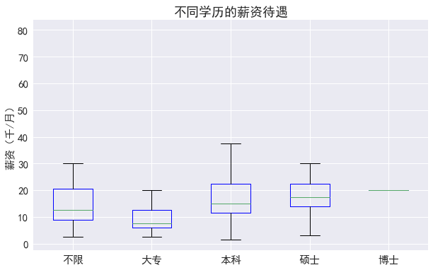

```python
plt.figure(figsize=(10,6));
plt.boxplot(salary_of_edu, boxprops = {'color':'blue'});
plt.title(u'不同学历的薪资待遇', size=18);
plt.ylabel(u'薪资（千/月）',size=15);
plt.xticks(np.arange(5)+1,edu_sort.index, size=15);
plt.yticks(size=15);
#plt.grid();
```

### 其中不限学历的可能由于招聘者忘记选择，也可能由于其是新兴领域，更看重实际能力而非学历，对于有明确要求的，大专明显低于本科和硕士，本科和硕士的差距倒不是特别大，只是硕士的起薪要高

## 工作技能要求：

```python
# 添加技能列
import re
def get_skill(text):
    skill_list = re.findall('([a-zA-Z][0-9a-zA-Z]+|C\#|\.Net|R\d?|A\/B|算法)', text)
    for skill in skill_list:
        if skill.upper() == 'EXCEL' or skill.upper() == 'PPT':
            skill_list[skill_list.index(skill)] = 'office'
    return ','.join(skill_list).upper()
df_clean['skill'] = df_clean['description'].apply(get_skill)
```

```python
# 生成技能字典
import nltk
skill_list = []
for i in df_clean.index:
    if len(df_clean.loc[i, 'skill']) > 0:
        skill_list.extend(df_clean.loc[i, 'skill'].split(','))

skill_freq = dict(nltk.FreqDist(skill_list))

# 删除主要的提取错误的键值
del skill_freq['AND']
del skill_freq['TO']
del skill_freq['IN']
del skill_freq['DATA']
del skill_freq['THE']
del skill_freq['OF']
del skill_freq['KPI']
del skill_freq['APP']
del skill_freq['WITH']
del skill_freq['SERVER']
skill_freq
```

[output not shown]

[output cut: 946 more lines]

[output not shown]

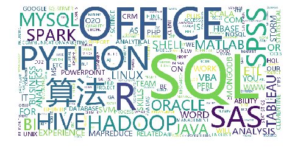

```python
wc = WordCloud(width=800, height=400, background_color='white').generate_from_frequencies(skill_freq)
plt.figure(figsize=(8,4));
plt.imshow(wc);
plt.axis('off');
plt.show();
```

### 可见，SQL，Office（主要是Excel和PPT）是需求最大的，是绝大多数要求必须掌握的；其次，Python,算法和R的需求也很大，另外SAS，SPSS，Hadoop，Hive的需求也不小

## 查看主流技能的薪酬平均中值：

```python
# 选取需求最多的20个技能
skill_sort = sorted(skill_freq.items(), key=lambda item:item[1], reverse=True) #对技能频数字典按值从大到小排序
hot_skill_list = skill_sort[0:20]
hot_skill_list
```

```
[('SQL', 1124),
 ('OFFICE', 1078),
 ('R', 736),
 ('PYTHON', 733),
 ('算法', 666),
 ('SAS', 580),
 ('SPSS', 491),
 ('HIVE', 344),
 ('HADOOP', 288),
 ('MYSQL', 242),
 ('BI', 198),
 ('SPARK', 195),
 ('ORACLE', 151),
 ('JAVA', 139),
 ('MATLAB', 115),
 ('TABLEAU', 109),
 ('ETL', 95),
 ('SHELL', 88),
 ('LINUX', 84),
 ('VBA', 57)]
```

```python
hot_skill_salary_mean = {} # 存放技能中值的均值的字典
for i in hot_skill_list: # i 为技能和其频次的列表的元素
    for j in df_clean.index:
        if i[0] in df_clean.loc[j, 'skill']: # 如果技能在数据框的技能列中
            if i[0] in hot_skill_salary_mean: # 如果技能在技能中值的均值的字典中
                # 技能键的值为原值加上新值
                hot_skill_salary_mean[i[0]] = hot_skill_salary_mean[i[0]] + df_clean.loc[j, 'salary_median']
            else:
                hot_skill_salary_mean[i[0]] = df_clean.loc[j, 'salary_median']
    hot_skill_salary_mean[i[0]] = hot_skill_salary_mean[i[0]] / i[1] # 技能中值的均值为之前计算的和除以技能频数

hot_skill_salary_mean = sorted(hot_skill_salary_mean.items(), key=lambda item:item[1]) #排序
hot_skill_salary_mean #排序后返回由含字典元素的元组构成的列表
```

```
[('OFFICE', 10.013450834879407),
 ('算法', 11.796546546546546),
 ('VBA', 13.771929824561404),
 ('ETL', 15.173684210526316),
 ('ORACLE', 15.665562913907285),
 ('MYSQL', 15.888429752066116),
 ('SPSS', 16.113034623217924),
 ('SAS', 16.402586206896551),
 ('BI', 16.926767676767678),
 ('TABLEAU', 17.004587155963304),
 ('PYTHON', 17.303547066848566),
 ('SQL', 17.387900355871885),
 ('MATLAB', 17.504347826086956),
 ('HADOOP', 18.364583333333332),
 ('SPARK', 19.207692307692309),
 ('HIVE', 19.228197674418606),
 ('SHELL', 19.261363636363637),
 ('LINUX', 19.589285714285715),
 ('JAVA', 20.176258992805757),
 ('R', 24.895380434782609)]
```

```python
hot_skill_freq = [] #把前20个技能的需求频数提取出来
for i in hot_skill_salary_mean:
    hot_skill_freq.append(skill_freq[i[0]])
hot_skill_freq # 排序会按其薪酬均值从小到大
```

```
[1078,
 666,
 57,
 95,
 151,
 242,
 491,
 580,
 198,
 109,
 733,
 1124,
 115,
 288,
 195,
 344,
 88,
 84,
 139,
 736]
```

```python
hot_skill_salary_key = [] # 热门技能名称列表
hot_skill_salary_values = [] #热门技能的中值的均值列表
for i,j in dict(hot_skill_salary_mean).items():
    hot_skill_salary_key.append(i)
    hot_skill_salary_values.append(j)
```

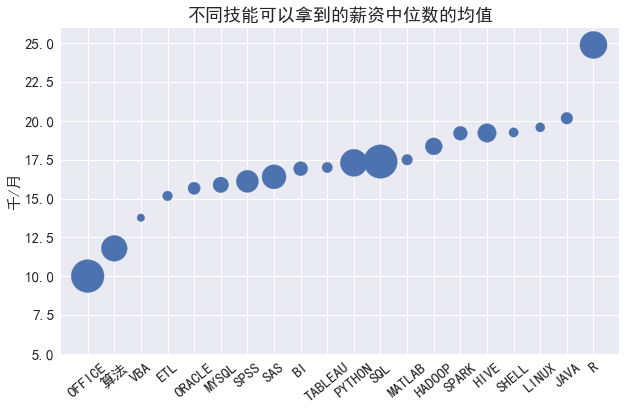

```python
plt.figure(figsize=(10,6));
plt.scatter(x = np.arange(len(hot_skill_salary_values)), y=hot_skill_salary_values, s=hot_skill_freq);
plt.xticks(np.arange(len(hot_skill_salary_values)), hot_skill_salary_key, size=15, rotation=40);
plt.yticks(size=15);
plt.title('不同技能可以拿到的薪资中位数的均值', size=18);
plt.ylabel('千/月', size=15);
plt.ylim((5,26));
```

### 圆点大小代表了需求量，从结果看，R薪资最高，这比较出人意料，算法太低，可能是由于大多数岗位需求里都提到了算法，进而拉低了其均值，如果进一步分析，应该能得出比较贴合实际的数据，或者如果太繁琐，也可直接将此项剔除，分析其它岗位如深度学习机器学习的薪资来得到算法的薪资均值。Java是走向高级开发必不可少的路，Hadoop，Spark，Hive仍然是数据分析类职位的高薪必备技能。

## 看看主要工作经验对主流技能的要求是否有差别：

```python
# 生成字典，来存放两种经验对应的主流技能需求数
skill_by_exp13 = {}
skill_by_exp35 = {}
df_skill_13 = df_clean[df_clean['experience']=='1-3年'][['experience', 'skill']]
df_skill_35 = df_clean[df_clean['experience']=='3-5年'][['experience', 'skill']]
for i in hot_skill_salary_key:
    for j in df_skill_13.index:
        if i in df_skill_13.loc[j, 'skill']:
            if i in skill_by_exp13:
                skill_by_exp13[i] = skill_by_exp13[i] + 1
            else:
                skill_by_exp13[i] = 1

for i in hot_skill_salary_key:
    for j in df_skill_35.index:
        if i in df_skill_35.loc[j, 'skill']:
            if i in skill_by_exp35:
                skill_by_exp35[i] = skill_by_exp35[i] + 1
            else:
                skill_by_exp35[i] = 1
```

```python
pd.Series(skill_by_exp13)
#skill_by_exp35
```

```
BI          55
ETL         22
HADOOP      71
HIVE        87
JAVA        43
LINUX       19
MATLAB      46
MYSQL       88
OFFICE     260
ORACLE      43
PYTHON     247
R          345
SAS        201
SHELL       26
SPARK       54
SPSS       162
SQL        396
TABLEAU     38
VBA         19
算法         142
dtype: int64
```

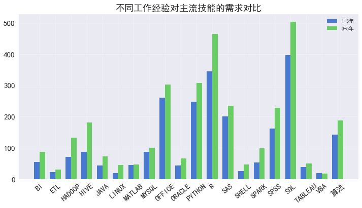

```python
ind = np.arange(len(skill_by_exp13))
width = 0.35
sns.set(context='notebook', style='darkgrid', palette='muted', font='simhei')
plt.figure(figsize=(12,6));
plt.grid(color='white', linewidth=1,alpha=0.3);
plt.bar(ind, pd.Series(skill_by_exp13).values, width,  label='1-3年');
plt.bar(ind + width, pd.Series(skill_by_exp35).values, width,  label='3-5年');
plt.title('不同工作经验对主流技能的需求对比', size=18);
plt.xticks(ind+width/2, pd.Series(skill_by_exp13).index, size=15, rotation=40);
plt.yticks(size=15)
plt.legend();
```

### 几乎所有主流技能，3-5年工作经验的需求量都比1-3年的多，但这很大可能是因为3-5年的招聘数本身就比1-3年的多100个左右，但我注意到，对Matlab、MySQL、VBA及Tableau的需求两者相差无几，VBA方面3-5年的甚至低于1-3年的，这说明3-5年经验要求的对这四种技能的需求不如1-3年的多。

## 结论汇总

### 7. 技能方面，office（主要是excel其次少部分PPT）和SQL需求最多，Python、R、算法紧随其后，Hadoop、SPSS、Hive、SAS、和Spark的需求也不少

### 8. 对于不同的技能可以拿到的高薪，R优势最大，其次是Java，Linux等，显然这已经不是基础的数据分析需要的技能了，可能侧重于数据挖掘等

### 9. 要求3-5年经验的和要求1-3年经验的在技能需求上没有太大差别

## 思考·总结

### 通过这次分析，深切的感受到了思路的重要性，如果你对探索数据没有好奇心，没有一点自己的想法，那真可谓无处下手，不知道该分析什么，正所谓思路为“道”，工具为“术”，分析之前，得先给自己提出几个想探索的问题，或想验证的设想，当然这一点不是非得一步到位，也可以循序渐进，随着分析的不断进行又想开展新的探索。“术”方面的工具技能也很重要，有时候你不知道那个函数的用法，不知道那个参数的设置，可能找很久都找不到，比如对柱状图添加文字说明，起初我按照搜索到的方法添加，可就是不出效果，搜了好几种方法都不行，无奈之下我只得把别人的代码截图一行一行敲下来运行验证，最后发现是因为没放在一个cell里这个低级原因，当然，这个过程中我又学到了别的知识。术方面还有一点需要说的是，早期seaborn包会对matplotlib的图自动美化，但新版改了，不会自动美化，得自己设置，这方面花了大量时间搜索，主要是不知道对应的术语叫什么，只能按文字描述搜索，最后发现，图像的灰底不是颜色，是style，可以用两种方式设置，但两种都不好用，因为只要对一个图设置后，那做其它图时都会默认采用你之前设置的style，我希望只针对单个图起作用。项目之外的，我感到主动学习非常重要，对于自己不会的，不要畏惧，也不要偷懒，要相信自己碰到的问题别人也绝对碰到过，搜一搜，看看别人是怎么解决的，比如对于技能的提取及词云的绘制，起初用了结巴分词提取，但提取有疏漏，不过没有大的问题，但绘制词云时，出来的都是中文词，基本没有技能名，我只好去找别的方法，看能不能过滤掉提取后的中文词，最后发现何不采用正则重新提取呢，于是进行了重新提取，但绘制词云时又碰到重复显示的问题，最后用自定义词典解决了。另外就是英语非常重要，有些函数的参数太多，以至于官网文档都没有详细说，它可能是作为一些共用的参数放在了其它函数介绍中。最后，对于岗位描述的探索还能进一步采用语义分析，得出更明确的要求，因为有些要求是必须满足的，有些是加分项，但水平所限，还不能语义分析，还有就是投资公司，如果数据较全也能探索下金融方面这些机构的投资偏好及相互间的裙带关系，毕竟，中国的互联网，谁都绕不开阿里腾讯及其背后的资本。